# Analysis of Mass Shootings in the United States from 1982 - 2022

#### Please note: It is recommended to view this notebook through a Jupyter Notebook Viewer. Click [this link](https://nbviewer.org/github/SpencerTimothy/Mass-Shootings-in-the-United-States/blob/main/U.S.%20Mass%20Shootings.ipynb), or navigate to: https://nbviewer.org/github/SpencerTimothy/Mass-Shootings-in-the-United-States/blob/main/U.S.%20Mass%20Shootings.ipynb to view in NBViewer.

Mass shootings in the United States have been a significant public health issue since 1982. To better understand the problem, this study aims to analyze data from [Mother Jones'](https://www.motherjones.com/politics/2012/12/mass-shootings-mother-jones-full-data/) mass shooting dataset covering the period from 1982 to 2022. The goal of the analysis is to answer key questions about the characteristics of mass shootings in the United States.

This analysis is organized into three sections: data cleaning, visualization, and geospatial visualization:

Overall, this analysis aims to provide a comprehensive understanding of mass shootings in the United States.

### Standard Imports for Data Visualization and Analysis

```python
# Standard imports

import pandas as pd
import seaborn as sns
import matplotlib.pyplot as plt
import pydeck as pdk
import math
```

```python
# Create DataFrame

df = pd.read_csv(r"C:\Users\Lenovo user\Downloads\Mass Shootings 1982 - 2022.csv")
```

```python
# See DataFrame

df.head()
```

|  | case | location | date | summary | fatalities | injured | total_victims | location.1 | age_of_shooter | prior_signs_mental_health_issues | ... | weapon_details | race | gender | sources | mental_health_sources | sources_additional_age | latitude | longitude | type | year |
| --- | --- | --- | --- | --- | --- | --- | --- | --- | --- | --- | --- | --- | --- | --- | --- | --- | --- | --- | --- | --- | --- |
| 0 | Virginia Walmart shooting | Chesapeake, Virginia | 11/22/22 | Andre Bing, 31, who worked as a supervisor at ... | 6 | 6 | 12 | Workplace | 31 | - | ... | - | Black | M | https://www.washingtonpost.com/dc-md-va/2022/1... | - | - | - | - | Mass | 2022 |
| 1 | LGBTQ club shooting | Colorado Springs, Colorado | 11/19/22 | Anderson L. Aldrich, 22, wore body armor and o... | 5 | 25 | 30 | Other | 22 | yes | ... | - | White | M | https://coloradosun.com/2022/11/20/club-q-shoo... | https://www.nytimes.com/2022/11/20/us/colorado... | - | - | - | Mass | 2022 |
| 2 | University of Virginia shooting | Charlottesville, Virginia | 11/13/22 | Christopher Darnell Jones Jr., 22, allegedly o... | 3 | 2 | 5 | School | 22 | - | ... | Glock 45 9mm; Ruger AR-556 rifle (in his dorm ... | Black | M | https://dailyprogress.com/news/local/guns-and-... | - | - | - | - | Mass | 2022 |
| 3 | Raleigh spree shooting | Hedingham, North Carolina | 10/13/22 | Austin Thompson, 15, went on a rampage in the ... | 5 | 2 | 7 | Other | 15 | - | ... | NaN | White | M | https://www.newsobserver.com/news/local/crime/... | - | - | - | - | Spree | 2022 |
| 4 | Greenwood Park Mall shooting | Greenwood, Indiana | 7/17/22 | Jonathan Sapirman, 20, opened fire in a mall f... | 3 | 2 | 5 | workplace | 20 | - | ... | Sig Sauer M400 rifle | White | M | https://apnews.com/article/indiana-mall-shooti... | - | - | - | - | Mass | 2022 |

5 rows × 24 columns

## **I.** Data Cleaning and Manipulation

During the data cleaning and manipulation process for this study, several missing data points were identified in the `injured`, `total_victims`, `age_of_shooter`, `longitude`, and `latitude` columns. To address these missing values, additional data was sourced from various local and international news sources. In some cases, definitive information was not available and estimates had to be made, such as the number of people injured in the Tulsa medical center shooting in 2022. To determine the `longitude` and `latitude` values for missing data, the location of each shooting was looked up on Google and the coordinates were copied and pasted into the dataset.

```python
# Fill in missing data

# One element in the injured column does not specify exactly how many people were injured.
df['injured'][8] = 5 # 5 because the total number is not known, and is said to be less than 10

# One element in the total_victims column does not specify exactly how many victims there were.
df['total_victims'][8] = df['injured'][8] + df['fatalities'][8] # nine because the total number of victims is not known

# Several elements in the age_of_shooter column do not specify the age of the shooter.
df['age_of_shooter'][8] = 45
df['age_of_shooter'][11] = 39
df['age_of_shooter'][15] = 43
df['age_of_shooter'][20] = math.ceil((47 + 50)/2) # average age of the two shooters
df['age_of_shooter'][21] = 21


# Fill in missing data for longitude and latitude

# Chesapeake, VA - Walmart - 1521 Sams Cir
df['latitude'][0] = 36.772754031243075
df['longitude'][0] = -76.24905678690314
# Colorado Springs - CO Club Q - 3430 N. Academy Blvd
df['latitude'][1] = 38.88119556497113
df['longitude'][1] = -104.75843700223267
# Charlottesville, VA - University of Virginia - Behind Drama Building
df['latitude'][2] = 38.03350732033033
df['longitude'][2] = -78.50804772182332
# Raleigh, NC - Hedingham Neighborhood - Various locations
df['latitude'][3] = 35.80961328993678
df['longitude'][3] = -78.54602766983633
# Greenwood, IN - Greenwood Park Mall - 1251 U.S. Hwy 31
df['latitude'][4] = 39.6337243960314
df['longitude'][4] = -86.12207040220913
# Highland Park, IL - 4th of July Parade - Central Ave. and 2nd St
df['latitude'][5] = 42.185317724946856
df['longitude'][5] = -87.80085900212657
# Birmingham, AL - St Stephen's Episcopal Church - 3775 Crosshaven Drive
df['latitude'][6] = 33.468763377210884
df['longitude'][6] = -86.73070607355466
# Smithsburg, MD - Columbia Machine - 12921 Bikle Rd
df['latitude'][7] = 39.66969814735299
df['longitude'][7] = -77.5628417310439
# Tulsa, OK - St Francis Hospital - 6161 S Yale Ave
df['latitude'][8] = 36.07192165002109
df['longitude'][8] = -95.91981100574812
# Uvalde, TX - Robb Elementary School - 715 Old Carrizo Rd
df['latitude'][9] = 29.199784756990283
df['longitude'][9] = -99.78812394482847
# Buffalo, NY - TOPS Friendly Markets - 1275 Jefferson Ave
df['latitude'][10] = 42.909867711460116
df['longitude'][10] = -78.85292409601568
```

[output not shown]

[output cut: 90 more lines]

[output not shown]

### Modify Data Types of Certain Columns

To facilitate mathematical operations and further analysis, the data types of certain columns were modified.

```python
# Change data types

#df['date'] = df['date'].astype('datetime64') # This causes trouble with pydeck
df['age_of_shooter'] = df['age_of_shooter'].astype('int64')
df['injured'] = df['injured'].astype('int64')
df['total_victims'] = df['total_victims'].astype('int64')
df['latitude'] = df['latitude'].astype('float64')
df['longitude'] = df['longitude'].astype('float64')
df['year'] = df['year'].astype('int64')
```

### Correct Grammar and Mistakes in Data Values

During the data cleaning process, various grammatical errors and inconsistencies were identified in some of the values, including the presence of unnecessary spaces, capitalization errors, and special characters such as `\n`. To improve the clarity and simplicity of the data, the values for "-" and "Unknown" were combined and any other identified errors were corrected. These "-" and "Unknown" values were originally used to indicate missing or unknown information in the dataset.

```python
# Format the 'location.1' column

# Strip extra whitespace and charactsrs
df['location.1'] = df['location.1'].str.strip()

# Make all location.1 have uppercase first letters
df['location.1'] = df['location.1'].str.capitalize()
```

```python
# Clean up the 'prior_signs_mental_health_issues' column

# Strip extra whitespace and characters
df['prior_signs_mental_health_issues'] = df['prior_signs_mental_health_issues'].str.strip()

# Make all location.1 have uppercase first letters
df['prior_signs_mental_health_issues'] = df['prior_signs_mental_health_issues'].str.capitalize()

# Replace '-', 'Unknown', and 'Unclear' with 'Other'
df['prior_signs_mental_health_issues'].replace(['-', 'Unknown', 'Unclear'], 'Unknown', inplace=True)
```

```python
# Clean the 'race' column

# Strip extra characters and spaces
df['race'] = df['race'].str.strip()

# Convert first letter to uppercase
df['race'] = df['race'].str.title() # .title() because of the 'Native American' catigory

# Replace all '-' values for 'Unknown' values
df['race'].replace('-', 'Unknown', inplace=True)
```

**Note:** In the `weapon_type` column, there were various descriptions of the weapons used in each incident. To simplify the data, a function was created to classify these weapons as "Handgun", "Rifle", or "Shotgun". Knives were not included in this classification, as the focus of the analysis is on mass shootings. The final steps involved converting the list of weapons into a string and replacing any "-" values with "Unknown".

```python
# Clean the 'weapon_type' column - sum the types of weapons to the general weapon type.

# Make function to loop through 'weapon_type'
def classify_weapon(weapon):

    # Create list to store appended values
    weapons = []

    # Check to see if specific values are in 'weapon', then append shortened version
    if 'handgun' in weapon.lower() or 'pistol' in weapon.lower() or 'revolver' in weapon.lower():
        weapons.append('Handgun')
    if 'rifle' in weapon.lower() or 'long gun' in weapon.lower():
        weapons.append('Rifle')
    if 'shotgun' in weapon.lower():
        weapons.append('Shotgun')
    # If none of the key words are in the column, then return the original value
    if not weapons:
        return weapon
    return weapons

# Apply the function to the 'weapon_type' column
df['weapon_type'] = df['weapon_type'].apply(classify_weapon)

# Change the lists to a string
df['weapon_type'] = df['weapon_type'].apply(lambda x: ', '.join(map(str, x)))

# Replace '-' with 'Unknown'
df['weapon_type'] = df['weapon_type'].replace('-', 'Unknown')
```

```python
# Clean 'gender' column

# Replace all 'M' and 'F' values with 'Male' and 'Female', repectively
df['gender'] = df['gender'].replace(['M', 'F'], ['Male', 'Female'])
```

```python
#See updated DataFrame

df.head()
```

|  | case | location | date | summary | fatalities | injured | total_victims | location.1 | age_of_shooter | prior_signs_mental_health_issues | ... | weapon_details | race | gender | sources | mental_health_sources | sources_additional_age | latitude | longitude | type | year |
| --- | --- | --- | --- | --- | --- | --- | --- | --- | --- | --- | --- | --- | --- | --- | --- | --- | --- | --- | --- | --- | --- |
| 0 | Virginia Walmart shooting | Chesapeake, Virginia | 11/22/22 | Andre Bing, 31, who worked as a supervisor at ... | 6 | 6 | 12 | Workplace | 31 | Unknown | ... | - | Black | Male | https://www.washingtonpost.com/dc-md-va/2022/1... | - | - | 36.772754 | -76.249057 | Mass | 2022 |
| 1 | LGBTQ club shooting | Colorado Springs, Colorado | 11/19/22 | Anderson L. Aldrich, 22, wore body armor and o... | 5 | 25 | 30 | Other | 22 | Yes | ... | - | White | Male | https://coloradosun.com/2022/11/20/club-q-shoo... | https://www.nytimes.com/2022/11/20/us/colorado... | - | 38.881196 | -104.758437 | Mass | 2022 |
| 2 | University of Virginia shooting | Charlottesville, Virginia | 11/13/22 | Christopher Darnell Jones Jr., 22, allegedly o... | 3 | 2 | 5 | School | 22 | Unknown | ... | Glock 45 9mm; Ruger AR-556 rifle (in his dorm ... | Black | Male | https://dailyprogress.com/news/local/guns-and-... | - | - | 38.033507 | -78.508048 | Mass | 2022 |
| 3 | Raleigh spree shooting | Hedingham, North Carolina | 10/13/22 | Austin Thompson, 15, went on a rampage in the ... | 5 | 2 | 7 | Other | 15 | Unknown | ... | NaN | White | Male | https://www.newsobserver.com/news/local/crime/... | - | - | 35.809613 | -78.546028 | Spree | 2022 |
| 4 | Greenwood Park Mall shooting | Greenwood, Indiana | 7/17/22 | Jonathan Sapirman, 20, opened fire in a mall f... | 3 | 2 | 5 | Workplace | 20 | Unknown | ... | Sig Sauer M400 rifle | White | Male | https://apnews.com/article/indiana-mall-shooti... | - | - | 39.633724 | -86.122070 | Mass | 2022 |

5 rows × 24 columns

```python
# See basic statistics

df.describe()
```

|  | fatalities | injured | total_victims | age_of_shooter | latitude | longitude | year |
| --- | --- | --- | --- | --- | --- | --- | --- |
| count | 137.000000 | 137.000000 | 137.000000 | 137.000000 | 137.000000 | 137.000000 | 137.000000 |
| mean | 7.839416 | 11.445255 | 19.284672 | 33.613139 | 37.394648 | -96.006799 | 2010.014599 |
| std | 7.553956 | 47.232828 | 52.464407 | 12.619574 | 5.494773 | 17.610915 | 10.732020 |
| min | 3.000000 | 0.000000 | 3.000000 | 11.000000 | 21.320063 | -157.876462 | 1982.000000 |
| 25% | 4.000000 | 1.000000 | 6.000000 | 22.000000 | 33.835420 | -115.171544 | 2004.000000 |
| 50% | 6.000000 | 3.000000 | 10.000000 | 32.000000 | 38.254238 | -88.902892 | 2014.000000 |
| 75% | 8.000000 | 10.000000 | 17.000000 | 43.000000 | 41.412323 | -81.294086 | 2018.000000 |
| max | 58.000000 | 546.000000 | 604.000000 | 70.000000 | 48.461367 | -71.075913 | 2022.000000 |

## **II.** Data Visualizations

### 1. Mean Age of Shooter

To visualize the distribution of ages among shooters, a graph will be created using Seaborn's `displot` function and Matplotlib's `axvline`. The `kde='true'` argument will be used to help with the visualization.

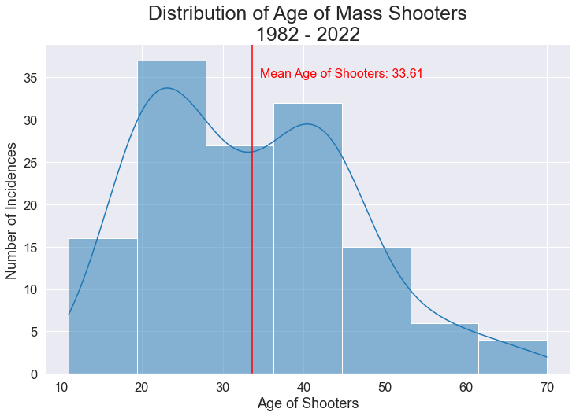

```python
# Create chart to see the age distribution of shooters

# Set style of charts
sns.set_style('darkgrid')

# Find mean age of shooters
mean_age_of_shooter = df['age_of_shooter'].mean()

# Make text bigger
sns.set_context('notebook', font_scale=1.5)

# Create chart
sns.displot(df, x="age_of_shooter", kde='true', bins=7, height=7, aspect=1.5)

# Plot mean age of shooter line and give it a label
plt.axvline(mean_age_of_shooter, color='r')
plt.text(x=mean_age_of_shooter+1, y=35, s='Mean Age of Shooters: {0:.2f}'.format(mean_age_of_shooter), fontsize=16, color='r')

# Give the chart a title and label axis
plt.title('Distribution of Age of Mass Shooters\n1982 - 2022', fontsize=25)
plt.ylabel('Number of Incidences')
plt.xlabel('Age of Shooters')

# Plot
plt.show()
```

### 2. Number of Victims per State

To determine the total number of victims per state, a new DataFrame called `vict_per_st` will be created. The `location` column will be split into two separate columns, `City` and `State`, and the unnecessary `City` column will be dropped. The `groupby()` function from pandas will be used to sum the `total_victims` by state, and the `reset_index()` function will be applied to transform the resulting data into a DataFrame.

```python
# Create new DataFrame to see Total Victims in all states

# Create new DataFrame to store data
vict_per_st = pd.DataFrame()

# Split the 'location' column and add them to seperate columns in the new DataFrame
vict_per_st[['City','State']] = df['location'].str.split(',', expand=True)

# Add 'total_victims' to the new DataFrame
vict_per_st['Total Victims'] = df['total_victims']

# Drop the 'City' column because it is not needed for this example
vict_per_st = vict_per_st.drop('City', axis='columns')

# Group the 'Total Victims' by the 'State' column
sum_vict = vict_per_st.groupby('State')['Total Victims'].sum()

# Give the DataFrame an index.. Note that if this method is not used, the 'State' column would be the index
sum_vict = sum_vict.reset_index()

# Sort values to descending to see what the output is - not necessary for final notebook
sum_vict.sort_values('Total Victims', ascending=False)
```

|  | State | Total Victims |
| --- | --- | --- |
| 23 | Nevada | 616 |
| 33 | Texas | 334 |
| 3 | California | 317 |
| 7 | Florida | 235 |
| 4 | Colorado | 182 |
| 10 | Illinois | 102 |
| 35 | Virginia | 88 |
| 25 | New York | 68 |
| 36 | Washington | 65 |
| 27 | Ohio | 56 |
| 29 | Oregon | 47 |
| 5 | Connecticut | 46 |
| 30 | Pennsylvania | 40 |
| 37 | Wisconsin | 37 |
| 8 | Georgia | 36 |
| 28 | Oklahoma | 30 |
| 26 | North Carolina | 30 |
| 18 | Michigan | 29 |
| 14 | Kentucky | 28 |
| 19 | Minnesota | 23 |
| 16 | Maryland | 23 |
| 6 | D.C. | 20 |
| 11 | Indiana | 20 |
| 1 | Arizona | 19 |
| 13 | Kansas | 17 |
| 31 | South Carolina | 17 |
| 20 | Mississippi | 15 |
| 2 | Arkansas | 15 |
| 32 | Tennessee | 15 |
| 22 | Nebraska | 13 |
| 21 | Missouri | 12 |
| 34 | Utah | 10 |
| 9 | Hawaii | 7 |
| 12 | Iowa | 7 |
| 17 | Massachusetts | 7 |
| 24 | New Jersey | 7 |
| 15 | Lousiana | 6 |
| 0 | Alabama | 3 |

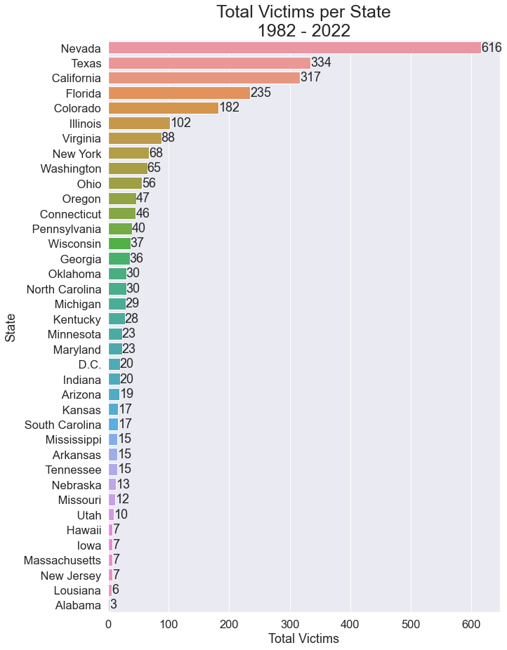

```python
# Visualize total victims per state

# Make chart larger to accomadate all values
plt.figure(figsize=(10,15))

# Create barplot
ax = sns.barplot(x='Total Victims', y='State', data=sum_vict.sort_values('Total Victims', ascending=False))

# Add labels to each of the bars
ax.bar_label(ax.containers[0])

# Add title
plt.title('Total Victims per State\n1982 - 2022', fontsize=25)

# Show the plot
plt.show()
```

**Observations:** According to the data, Nevada has the highest number of total victims from 1982 to 2022. This is largely due to the 2017 Las Vegas mass shooting, which resulted in approximately 604 total victims. It should be noted that only two mass shootings in Nevada were included in this dataset.

### 3. Total Shootings per State

To analyze the total number of shootings in each state, a similar process to the one used in the previous visualization will be followed.

```python
# Create new DataFrame to see Total Victims in all states

# Create new DataFrame to store data
inci_per_st = pd.DataFrame()

# Split the 'location' column and add them to seperate columns in the new DataFrame
inci_per_st[['City','State']] = df['location'].str.split(',', expand=True)

# Add 'total_victims' to the new DataFrame
inci_per_st['Number of Shootings'] = df['total_victims']

# Drop the 'City' column because it is not needed for this example
inci_per_st = inci_per_st.drop('City', axis='columns')

# Group the 'Total Victims' by the 'State' column
sum_inci = inci_per_st.groupby('State')['Number of Shootings'].size()

# Turn Series into DataFrame
sum_inci = sum_inci.reset_index()

# See what the output is - not necessary for final product
sum_inci.sort_values('Number of Shootings', ascending=False)
```

|  | State | Number of Shootings |
| --- | --- | --- |
| 3 | California | 23 |
| 7 | Florida | 12 |
| 33 | Texas | 12 |
| 4 | Colorado | 8 |
| 36 | Washington | 7 |
| 37 | Wisconsin | 5 |
| 30 | Pennsylvania | 5 |
| 10 | Illinois | 5 |
| 25 | New York | 5 |
| 35 | Virginia | 4 |
| 16 | Maryland | 4 |
| 27 | Ohio | 4 |
| 8 | Georgia | 3 |
| 5 | Connecticut | 3 |
| 18 | Michigan | 3 |
| 26 | North Carolina | 3 |
| 23 | Nevada | 2 |
| 32 | Tennessee | 2 |
| 31 | South Carolina | 2 |
| 29 | Oregon | 2 |
| 28 | Oklahoma | 2 |
| 19 | Minnesota | 2 |
| 21 | Missouri | 2 |
| 14 | Kentucky | 2 |
| 11 | Indiana | 2 |
| 22 | Nebraska | 1 |
| 24 | New Jersey | 1 |
| 20 | Mississippi | 1 |
| 1 | Arizona | 1 |
| 17 | Massachusetts | 1 |
| 15 | Lousiana | 1 |
| 13 | Kansas | 1 |
| 12 | Iowa | 1 |
| 9 | Hawaii | 1 |
| 34 | Utah | 1 |
| 6 | D.C. | 1 |
| 2 | Arkansas | 1 |
| 0 | Alabama | 1 |

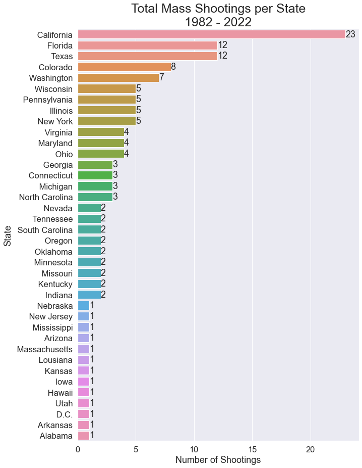

```python
# Visualize total victims per state

# Make chart larger to accomadate all values
plt.figure(figsize=(10,15))

# Create barplot
ax = sns.barplot(x='Number of Shootings', y='State', data=sum_inci.sort_values('Number of Shootings', ascending=False))

# Add labels to each of the bars
ax.bar_label(ax.containers[0])

# Add title
plt.title('Total Mass Shootings per State\n1982 - 2022', fontsize=25)

# Show the plot
plt.show()
```

**Observations:** While Nevada had the highest number of total victims in the previous visualization, it only had two mass shootings included in the dataset. In contrast, California had the highest number of mass shootings, with a total of 23 incidents. Texas and Florida had the second and third highest number of mass shootings, respectively, but Texas had more casualties than California, with 334 total victims in Texas compared to 317 total victims in California.

### 4. Total Victims Each Year

To analyze the total number of victims per year, a new DataFrame called `vict_per_year` will be created, and the `lambda` function will be used to slice the first two characters from the `year` column in order to shorten the x-axis on the resulting chart.

```python
# Create new DataFrame to see total victims each year

# Group the 'Total Victims' by the 'State' column
vict_per_year = df.groupby('year')['total_victims'].sum()

# Give the DataFrame an index.. Note that if this method is not used, the 'State' column would be the index
vict_per_year = vict_per_year.reset_index()

# Remove first two characters from 'year' to save room in visualization
vict_per_year['year'] = vict_per_year['year'].apply(lambda x: str(x)[2:])

# Only to see output - not necessary for final notebook
vict_per_year
```

|  | year | total_victims |
| --- | --- | --- |
| 0 | 82 | 11 |
| 1 | 84 | 48 |
| 2 | 86 | 21 |
| 3 | 87 | 20 |
| 4 | 88 | 11 |
| 5 | 89 | 56 |
| 6 | 90 | 14 |
| 7 | 91 | 61 |
| 8 | 92 | 19 |
| 9 | 93 | 57 |
| 10 | 94 | 28 |
| 11 | 95 | 6 |
| 12 | 96 | 7 |
| 13 | 97 | 14 |
| 14 | 98 | 50 |
| 15 | 99 | 89 |
| 16 | 00 | 7 |
| 17 | 01 | 9 |
| 18 | 03 | 15 |
| 19 | 04 | 12 |
| 20 | 05 | 26 |
| 21 | 06 | 28 |
| 22 | 07 | 85 |
| 23 | 08 | 41 |
| 24 | 09 | 78 |
| 25 | 10 | 11 |
| 26 | 11 | 40 |
| 27 | 12 | 151 |
| 28 | 13 | 48 |
| 29 | 14 | 46 |
| 30 | 15 | 89 |
| 31 | 16 | 154 |
| 32 | 17 | 704 |
| 33 | 18 | 150 |
| 34 | 19 | 185 |
| 35 | 20 | 9 |
| 36 | 21 | 59 |
| 37 | 22 | 183 |

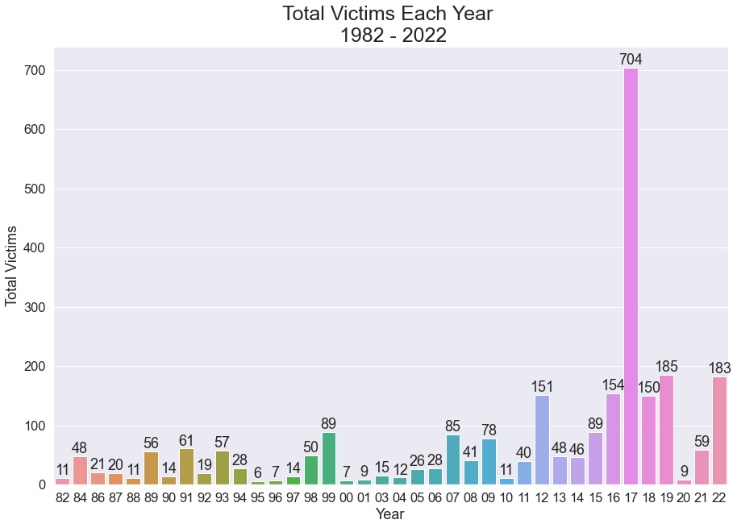

```python
# Set size of graph
plt.figure(figsize=(15,10))

# Create barplot
ax1 = sns.barplot(data=vict_per_year, y='total_victims', x='year')

# Add labels to each of the bars
ax1.bar_label(ax1.containers[0])

# Set titles
plt.title('Total Victims Each Year \n 1982 - 2022', fontsize=25)
plt.xlabel('Year')
plt.ylabel('Total Victims')

# Show the plot
plt.show()
```

**Observations:** For this chart we see that the number of total victims per year of mass shootings has be raising since around the mid 90's. The highest year was 2017 with 704 casualties. Again this was mainly because of the Las Vegas massacre where there were 604 total victims. It is worth noting that there were a few years with no recorded mass shootings, including 1983, 1985, and 2002.

### 5. Number of Shootings per Year and Location of Shootings

The next chart will show the number of shootings per year, as well as the locations where these shootings occurred. A kernel density estimate plot (KDE) will be included to illustrate the trends in shooting locations over time. A separate chart will also be included in the following cell to display the number of mass shootings per location type.

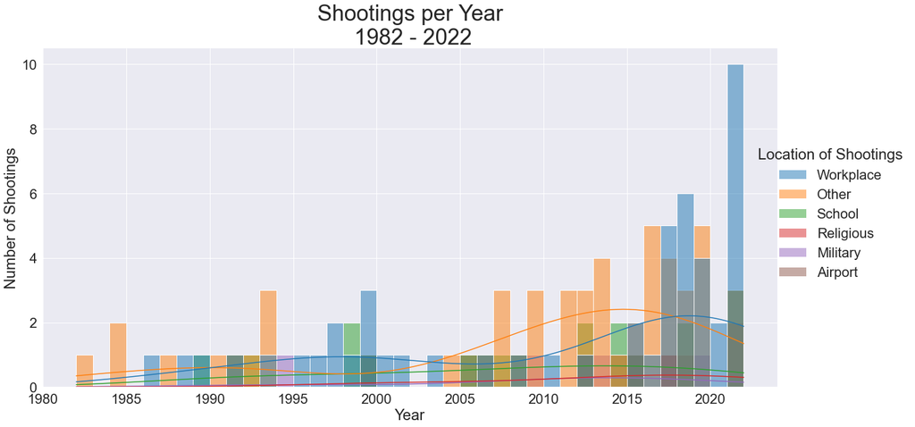

```python
# Create chart that shows shootings per year while staking the location of the shootings

# Set font size
sns.set_context('notebook', font_scale=2)

# Create displot with hue equal to the location of the shooting, and the number of beens equal to the number of years
ax2 = sns.displot(df, x='year', bins=df['year'].iloc[0] - df['year'].iloc[-1], height=9, aspect=2, hue='location.1', kde='true')

# Create title and lable the axis
plt.title('Shootings per Year\n 1982 - 2022', fontsize=35)
plt.xlabel('Year')
plt.ylabel('Number of Shootings')

# Create legend and legend title
legend = ax2._legend
legend.set_title("Location of Shootings")

# Show plot
plt.show()
```

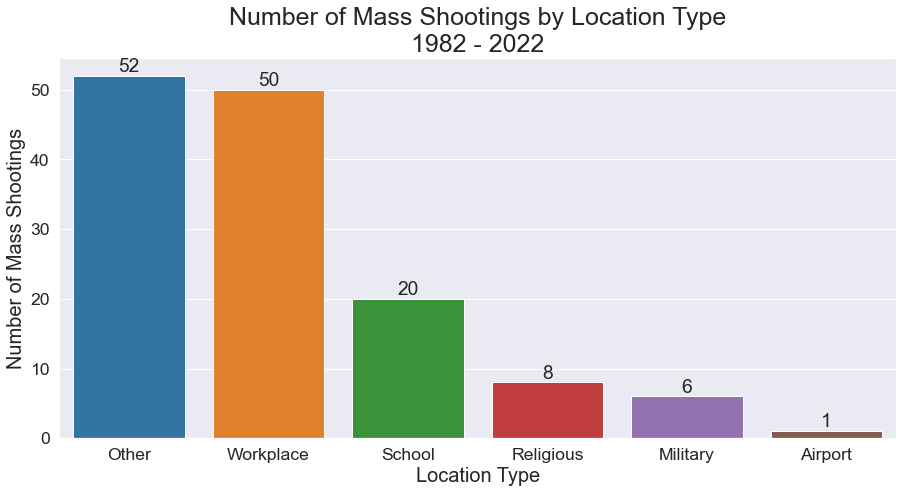

```python
# Create chart to show the most incidenses per location

# Set the figure size
plt.figure(figsize=(15,7))

# Set size of the font
sns.set_context('notebook', font_scale=1.6)


# Create the bar chart
ax3 = sns.barplot(x=df['location.1'].value_counts().index, y=df['location.1'].value_counts())

# Add the number of occurences to the top of the box
ax3.bar_label(ax3.containers[0])


# Add labels and titles
plt.xlabel('Location Type', fontsize=20)
plt.ylabel('Number of Mass Shootings', fontsize=20)
plt.title('Number of Mass Shootings by Location Type\n1982 - 2022', fontsize=25)

# Show the plot
plt.show()
```

**Observations:** The KDE plot in the chart shows that shootings in the workplace have consistently been a common location for mass shootings and have often been the most prevalent location for such incidents. "Other" is the most common location for mass shootings.

### 6. Prior Signs of Mental Health Issues

The `prior_signs_mental_health_issues` column will be analyzed using a seaborn `barplot()`. Some values in this column are labeled as "Unclear" and "-" and have been changed to "Unknown" for the purposes of this analysis. "Tbd" values, which indicate that it has not been publicly disclosed whether there were prior signs of mental health issues, are mostly from more recent mass shootings.

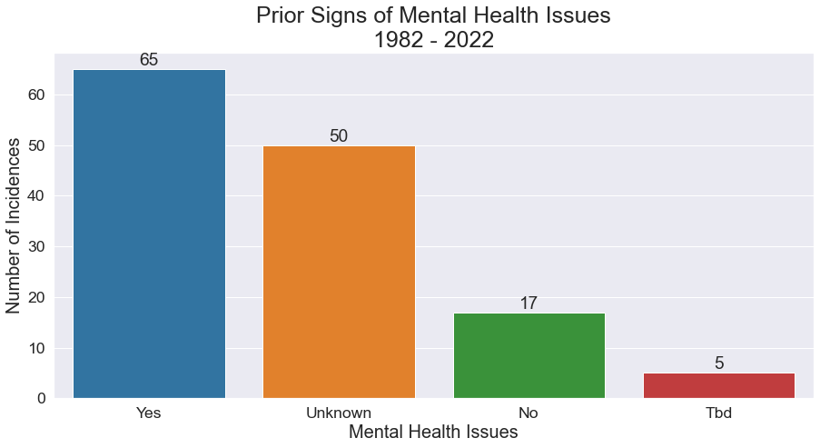

```python
# Create chart to show the most incidenses per location

# Set the figure size
plt.figure(figsize=(15,7))

# Set size of the font
sns.set_context('notebook', font_scale=1.6)

# Create the bar chart
ax4 = sns.barplot(x=df['prior_signs_mental_health_issues'].value_counts().index, y=df['prior_signs_mental_health_issues'].value_counts())

# Add the number of occurences to the top of the box
ax4.bar_label(ax4.containers[0])

# Add labels and titles
plt.xlabel('Mental Health Issues', fontsize=20)
plt.ylabel('Number of Incidences', fontsize=20)
plt.title('Prior Signs of Mental Health Issues\n1982 - 2022', fontsize=25)

# Show the plot
plt.show()
```

**Observations:** From the barplot, it appears that a significant proportion of mass shooters had prior signs of mental health issues. However, it is also worth noting that a significant number of cases had "unknown" or "unclear" information regarding the shooter's mental health history. This may indicate a need for further investigation and data collection on the relationship between mental health and mass shootings.

### 7. Mass Shootings by Race of Shooter

In this analysis, we examine the race of the shooters involved in mass shootings in the United States from 1982 to 2022. Several entries in the data set were listed as "-" and were replaced with "Unknown" in this analysis. Many of the "Unknown" shooters were involved in more recent shootings, and it would have required extensive research to determine their race. We chose not to pursue this research due to the value placed on accurately and respectfully representing the race of the shooters.

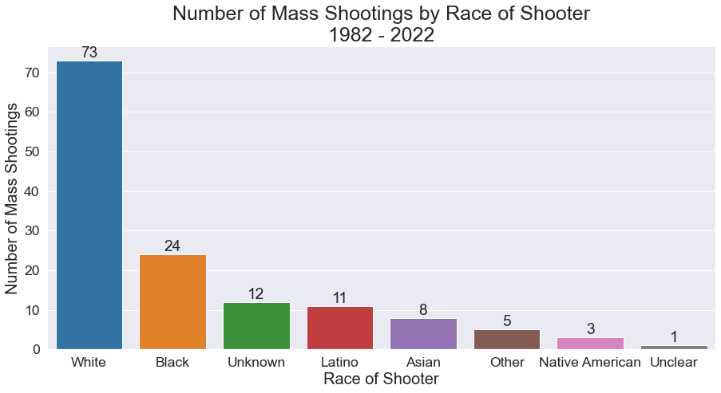

```python
# Set the figure size
plt.figure(figsize=(15,7))

# Set font size
sns.set_context('notebook', font_scale=1.6)

# Create a bar chart
ax5 = sns.barplot(x=df['race'].value_counts().index, y=df['race'].value_counts().values)

# Add values counts to the top of the bar
ax5.bar_label(ax5.containers[0])

# Add labels and a title
plt.xlabel('Race of Shooter', fontsize=20)
plt.ylabel('Number of Mass Shootings', fontsize=20)
plt.title('Number of Mass Shootings by Race of Shooter\n1982 - 2022', fontsize=25)

# Show the plot
plt.show()
```

**Observations:** "White" shooters have been the most common perpetrators of mass shootings in the United States, followed by "Black", "Unkown", and "Latino" shooters. It is important to note that these results do not necessarily reflect the overall racial demographics of the United States, as reported by the [Wikipedia](https://en.wikipedia.org/wiki/Race_and_ethnicity_in_the_United_States#:~:text=As%20of%202020%2C%20White%20Americans,minority%2C%20making%20up%2012.1%25.) page:

> As of 2020, White Americans are the racial and ethnic majority, with non-Hispanic whites representing 57.8% of the population. Hispanic and Latino Americans are the largest ethnic minority, comprising 18.7% of the population, while Black or African Americans are the second largest racial minority, making up 12.1%.

### 8. Most Common Weapon Types Used

In the following chart, the weapon type data was cleaned and summarized. It is noteworthy that "rifle" and "handgun" were originally classified under various names, such as "semi-automatic rifle", "semiautomatic rifle", "long gun", "semiautomatic handgun", "handguns", "revolver", etc. For the purposes of this analysis, these categories were simplified as "Rifle", "Handgun", and "Shotgun". In many of the mass shootings, the shooter used more than one weapon type. Instead of breaking these categories down further, such as "Semiautomatic Rifle, Long Gun, Revolver, Semiautomatic Handgun", it was decided to simply classify them with all the weapons used, for example: "Handgun", "Rifle", "Rifle, Handgun" or "Handgun, Shotgun" etc. The weapon categorizations were often broad, so it was not deemed necessary to conduct additional research on the specific weapon type for each incident. In most cases, both handguns and rifles used were "Semiautomatic".

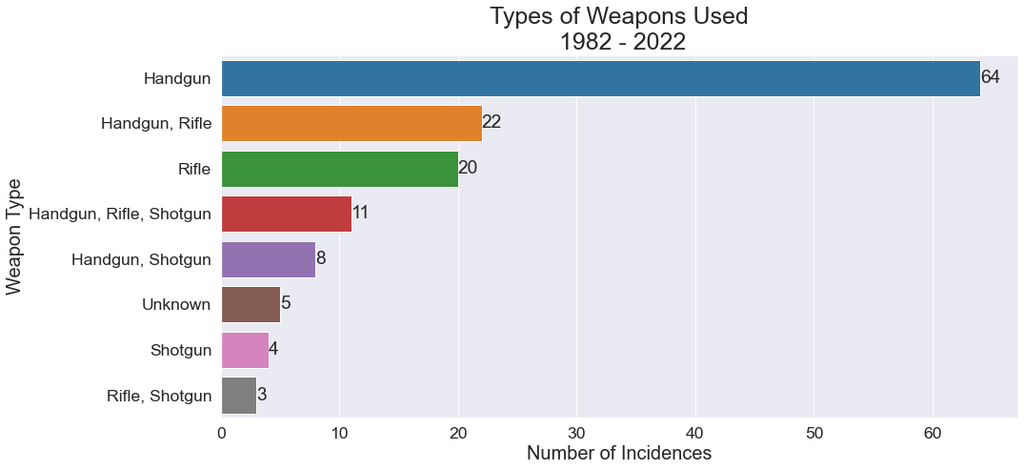

```python
# Create chart to show types of weapons used

# Set the figure size
plt.figure(figsize=(15,7))

# Set font size
sns.set_context('notebook', font_scale=1.6)

# Make barplot
ax6 = sns.barplot(y=df['weapon_type'].value_counts().index, x=df['weapon_type'].value_counts())

# Add value counts to the end of the bars
ax6.bar_label(ax6.containers[0])

# Add title and label axis
plt.xlabel('Number of Incidences', fontsize=20)
plt.ylabel('Weapon Type', fontsize=20)
plt.title('Types of Weapons Used\n 1982 - 2022', fontsize=25)

# Show plot
plt.show()
```

**Observations:** The analysis of weapon type usage in mass shootings in the United States reveals that "Handgun" was the most commonly used weapon, followed by a combination of "Handgun" and "Rifle", and then "Rifle" as the third most commonly used weapon.

### 9. Total Number of Fatalities, Injuries, and Total Victims of All Mass Shootings

In this section, we will use Seaborn's `barplot` function to visualize the total number of fatalities, injuries, and total victims from all mass shootings in the United States from 1982 to 2022. To do this, we will create a new DataFrame called `sum_all` and use the `sum()` and `sort_values()` methods from the Pandas library to calculate the sum total and create an ascending bar chart. This will allow us to gain a better understanding of the overall impact of mass shootings on victims and their families.

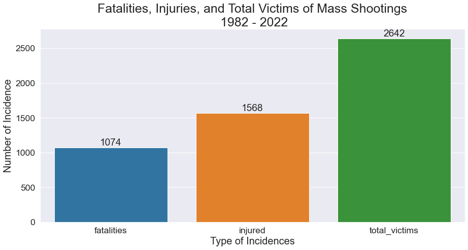

```python
# Plot total number of injuries, fatalities, and total victim counts

# Creat new DataFrame with the sum of each of the desired columns
sum_all = df[['injured', 'fatalities', 'total_victims']].sum()

# Sort the new DataFrame from smallest number to largest
sum_all.sort_values(inplace=True)

# Set the figure size
plt.figure(figsize=(15,7))

# Set font size
sns.set_context('notebook', font_scale=1.6)

# Create a new barplot
ax8 = sns.barplot(x=sum_all.index, y=sum_all.values)

# Add values to the top of each bar
ax8.bar_label(ax8.containers[0])

# Add title and label axis
plt.xlabel('Type of Incidences', fontsize=20)
plt.ylabel('Number of Incidence', fontsize=20)
plt.title('Fatalities, Injuries, and Total Victims of Mass Shootings\n 1982 - 2022', fontsize=25)

# Show plot
plt.show()
```

**Observations:** Our analysis has shown that there have been a total of 1074 fatalities, 1568 injuries, and 2642 total victims of mass shootings in the United States from 1982 to 2022. This indicates that mass shootings have had a significant impact on victims and their families, with more individuals being injured than killed in these incidents.

## III. Plotting all Mass Shootings in the United States

To visualize all the mass shootings in the United States, for this analysis it is necessary to plot all shootings from 1982 - 2022 using an interactive geospatial library called pydeck. The height of the columns will correspond to the `total_victims` column. The `elevation_scale` and the `radius` were increased to enhance the visual appeal of the chart. An interactive tooltip has been added to this chart that displays the "City, State" from the `location` column, the date of the incidence from the `date` column, and the "total victims" from the `total_victims` column when hovering over a data point. To interact with this map, the following actions are available:

- **Zoom:** The map can be zoomed in and out by double clicking, or double tapping with a touchpad.
- **Pan:** The map can be panned (moved horizontally or vertically) by clicking and dragging the map with a mouse or using a one-finger drag gesture on a touchpad.
- **Pitch & Bearing:** The pitch (the angle at which the map is tilted) and/or the bearing (the direction in which the map is rotated) of the map can be changed by clicking and dragging the cursor while holding the `Ctrl` + the left mouse button and moving the cursor up/down (pitch) or left/right (bearing), or by holding the right mouse button and moving the cursor up/down or left/right.

#### Please note: If chart does not appear, click [this link](https://nbviewer.org/github/SpencerTimothy/Mass-Shootings-in-the-United-States/blob/main/U.S.%20Mass%20Shootings.ipynb), or navigate to: https://nbviewer.org/github/SpencerTimothy/Mass-Shootings-in-the-United-States/blob/main/U.S.%20Mass%20Shootings.ipynb to view in NBViewer.

```python
# Make pydeck plot to visualize each shooting using ColumnLayer with the longitude and latitude of each
# shooting and setting the elevation of each column to the amount of people injured in each location

# Set view
view = pdk.ViewState(latitude=df['latitude'].mean(), longitude=df['longitude'].mean() - 4, zoom=3.5, bearing=25, pitch = 50)

# Create layer
mass_shootings_column_layer = pdk.Layer(
    "ColumnLayer",
    data=df,
    get_position=["longitude", "latitude"],
    get_elevation="total_victims",
    elevation_scale=10000,
    radius=25000,
    get_fill_color=["total_victims*5", 0, "total_victims*100", 150],
    pickable=True,
    auto_highlight=True
)

# Set tooltip
tooltip = {
    "html": "<center><b>{location}</b> <br> <b>{date}</b> <br> <b>{total_victims}</b> total victims</center>",
    "style": {"background": "grey", "color": "white", "font-family": '"Helvetica Neue", Arial', "z-index": "10000"},
}


# Make deck for map visualization
deck = pdk.Deck(
    mass_shootings_column_layer,
    initial_view_state=view,
    tooltip=tooltip
)

# Render to HTML
deck.to_html("mass_shootings_column_layer.html")

# If using something else other than Jupyter Notebook, use this line of code bellow
# deck.to_html("mass_shootings_column_layer.html", notebook_display=False)
```

[interactive chart not shown]

## IV. Conclusion

```python
print("Thanks for reading!")
```

```
Thanks for reading!
```